# Practical Machine : Prediction Assignment Writeup

H.C.Ng

January 23, 2016

# Data

The training data for this project are available here: https://d396qusza40orc.cloudfront.net/predmachlearn/pml-training.csv

The test data are available here: https://d396qusza40orc.cloudfront.net/predmachlearn/pml-testing.csv

```r
#loading the data into variables
Trainingdata <-read.csv("pml-training.csv", na.strings=c("", "NA", "NULL"))
Testingdata <-read.csv("pml-testing.csv", na.strings=c("", "NA", "NULL"))
dim(Trainingdata)
```

```
## [1] 19622   160
```

```r
dim(Testingdata)
```

```
## [1]  20 160
```

## Pre-screening the data

- Remove NA values from the file as there are lot of NA values in the file.

```r
training_na <- Trainingdata[ , colSums(is.na(Trainingdata)) == 0]
dim(training_na)
```

```
## [1] 19622    60
```

```r
# remove unrelevant variables
remove = c('X', 'user_name', 'raw_timestamp_part_1', 'raw_timestamp_part_2', 'cvtd_timestamp', 'new_window', 'num_window')
training_clean<- training_na[, -which(names(training_na) %in% remove)]
dim(training_clean)
```

```
## [1] 19622    53
```

```r
## checking on the variables the extremely low variance
# only numeric variabls can be evaluated in this way.
zeroVar= nearZeroVar(training_clean[sapply(training_clean, is.numeric)], saveMetrics = TRUE)
trainingnonzerovar = training_clean[,zeroVar[, 'nzv']==0]
dim(trainingnonzerovar)
```

```
## [1] 19622    53
```

```r
## Remove highly correlated variables 90%
# only numeric variabls can be evaluated in this way.
corrMatrix <- cor(na.omit(trainingnonzerovar[sapply(trainingnonzerovar, is.numeric)]))
dim(corrMatrix)
```

```
## [1] 52 52
```

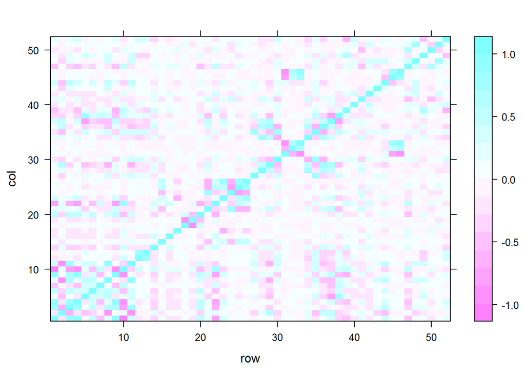

```r
# there are 52 variables.
corrDF <- expand.grid(row = 1:52, col = 1:52)
corrDF$correlation <- as.vector(corrMatrix)
levelplot(correlation ~ row+ col, corrDF)
```

```r
# remove those variable which have high correlation
removecor = findCorrelation(corrMatrix, cutoff = .90, verbose = TRUE)
```

```
## Compare row 10  and column  1 with corr  0.992
##   Means:  0.27 vs 0.168 so flagging column 10
## Compare row 1  and column  9 with corr  0.925
##   Means:  0.25 vs 0.164 so flagging column 1
## Compare row 9  and column  4 with corr  0.928
##   Means:  0.233 vs 0.161 so flagging column 9
## Compare row 8  and column  2 with corr  0.966
##   Means:  0.245 vs 0.157 so flagging column 8
## Compare row 19  and column  18 with corr  0.918
##   Means:  0.091 vs 0.158 so flagging column 18
## Compare row 46  and column  31 with corr  0.914
##   Means:  0.101 vs 0.161 so flagging column 31
## Compare row 46  and column  33 with corr  0.933
##   Means:  0.083 vs 0.164 so flagging column 33
## All correlations <= 0.9
```

```r
trainingdecor = trainingnonzerovar[,-removecor]
dim(trainingdecor)
```

```
## [1] 19622    46
```

In the end 19622 and 46 variables after all the cleaning process.

## Split data to training and testing for cross validation.

```r
inTrain <- createDataPartition(y=trainingdecor$classe, p=0.7, list=FALSE)
training <- trainingdecor[inTrain,]
testing <- trainingdecor[-inTrain,]
dim(training)
```

```
## [1] 13737    46
```

```r
dim(testing)
```

```
## [1] 5885   46
```

In the file,there are 13737 samples and 46 variables for training, 5885 samples and 46 variables for testing.

# Analysis

## Regression Tree

It is time to summarize and plot the data. First, we use the ‘tree’ package. It is much faster than ‘caret’ package.

```r
set.seed(3)
tree.training=tree(classe~.,data=training)
summary(tree.training)
```

```
##
## Classification tree:
## tree(formula = classe ~ ., data = training)
## Variables actually used in tree construction:
##  [1] "pitch_forearm"     "magnet_belt_y"     "accel_forearm_z"
##  [4] "magnet_dumbbell_y" "roll_forearm"      "magnet_dumbbell_z"
##  [7] "pitch_belt"        "yaw_belt"          "accel_dumbbell_y"
## [10] "accel_forearm_y"   "accel_forearm_x"   "magnet_arm_x"
## [13] "accel_dumbbell_z"
## Number of terminal nodes:  24
## Residual mean deviance:  1.503 = 20610 / 13710
## Misclassification error rate: 0.2845 = 3908 / 13737
```

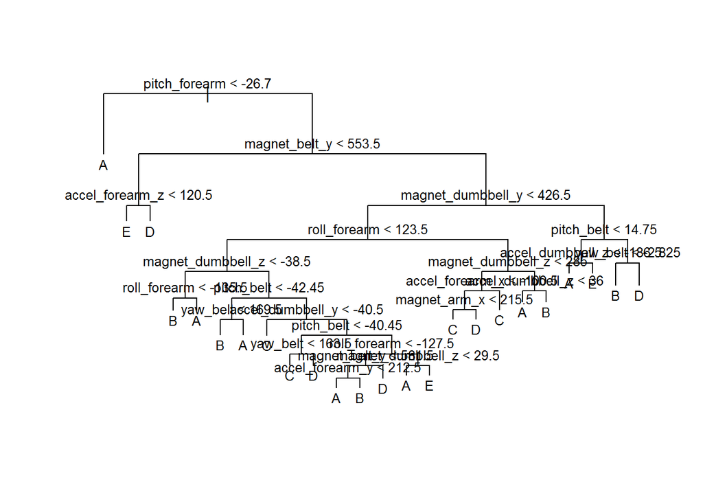

```r
plot(tree.training)
text(tree.training,pretty=0, cex =.8)
```

This is a bushy tree, and we are going to prune it.

Rpart form Caret,which is very slow.

```r
modFit <- train(classe ~ .,method="rpart",data=training)
print(modFit$finalModel)
```

```
## n= 13737
##
## node), split, n, loss, yval, (yprob)
##       * denotes terminal node
##
##  1) root 13737 9831 A (0.28 0.19 0.17 0.16 0.18)
##    2) pitch_forearm< -26.7 1220   54 A (0.96 0.044 0 0 0) *
##    3) pitch_forearm>=-26.7 12517 9777 A (0.22 0.21 0.19 0.18 0.2)
##      6) magnet_belt_y>=555.5 11484 8747 A (0.24 0.23 0.21 0.18 0.15)
##       12) magnet_dumbbell_y< 426.5 9441 6790 A (0.28 0.18 0.24 0.17 0.12)
##         24) roll_forearm< 123.5 5902 3505 A (0.41 0.18 0.18 0.14 0.086) *
##         25) roll_forearm>=123.5 3539 2311 C (0.072 0.17 0.35 0.23 0.18)
##           50) accel_forearm_x>=-101.5 2420 1464 C (0.084 0.21 0.4 0.086 0.23) *
##           51) accel_forearm_x< -101.5 1119  529 D (0.046 0.098 0.24 0.53 0.086) *
##       13) magnet_dumbbell_y>=426.5 2043 1132 B (0.042 0.45 0.04 0.21 0.26) *
##      7) magnet_belt_y< 555.5 1033  198 E (0.0029 0.0039 0.0019 0.18 0.81) *
```

# Cross Validation

We are going to check the performance of the tree on the testing data by cross validation.

```r
tree.pred=predict(tree.training,testing,type="class")
predMatrix = with(testing,table(tree.pred,classe))
sum(diag(predMatrix))/sum(as.vector(predMatrix)) # error rate
```

```
## [1] 0.7002549
```

The 0.70 is not very accurate count.

```r
tree.pred=predict(modFit,testing)
predMatrix = with(testing,table(tree.pred,classe))
sum(diag(predMatrix))/sum(as.vector(predMatrix)) # error rate
```

```
## [1] 0.4915888
```

The 0.50 from ‘caret’ package is much lower than the result from ‘tree’ package.

## Pruning tree

This tree was grown to full depth, and might be too variable. We now use Cross Validation to prune it.

```r
cv.training=cv.tree(tree.training,FUN=prune.misclass)
cv.training
```

```
## $size
##  [1] 24 23 22 21 19 18 17 16 15  9  7  5  1
##
## $dev
##  [1] 4088 4148 4301 4844 4966 4966 5017 5128 5140 6598 6598 7248 9831
##
## $k
##  [1]     -Inf  64.0000  99.0000 135.0000 143.0000 144.0000 149.0000
##  [8] 153.0000 162.0000 197.8333 198.5000 264.5000 654.5000
##
## $method
## [1] "misclass"
##
## attr(,"class")
## [1] "prune"         "tree.sequence"
```

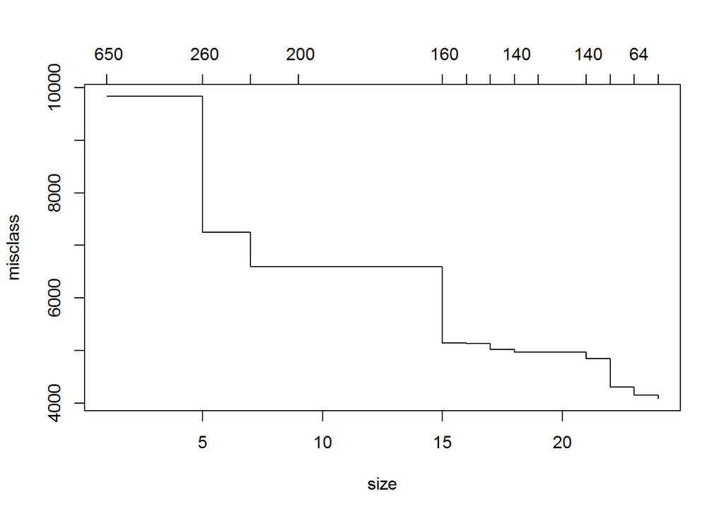

```r
plot(cv.training)
```

Suppose we prune it at size of nodes at 18.

```r
prune.training=prune.misclass(tree.training,best=18)
```

Now lets evaluate this pruned tree on the test data.

```r
tree.pred=predict(prune.training,testing,type="class")
predMatrix = with(testing,table(tree.pred,classe))
sum(diag(predMatrix))/sum(as.vector(predMatrix)) # error rate
```

```
## [1] 0.6596432
```

The single tree is not good enough, so we are going to use bootstrap to improve the accuracy. We are going to try random forests.

# Random Forests

These methods use trees as building blocks to build more complex models.

## Random Forests

Random forests build lots of bushy trees, and then average them to reduce the variance.

```r
require(randomForest)
set.seed(6)
rf.training=randomForest(classe~.,data=training,ntree=100, importance=TRUE)
rf.training
```

```
##
## Call:
##  randomForest(formula = classe ~ ., data = training, ntree = 100,      importance = TRUE)
##                Type of random forest: classification
##                      Number of trees: 100
## No. of variables tried at each split: 6
##
##         OOB estimate of  error rate: 0.65%
## Confusion matrix:
##      A    B    C    D    E class.error
## A 3902    2    2    0    0 0.001024066
## B   11 2635   12    0    0 0.008653123
## C    0   19 2374    2    1 0.009181970
## D    0    0   30 2220    2 0.014209591
## E    0    0    1    7 2517 0.003168317
```

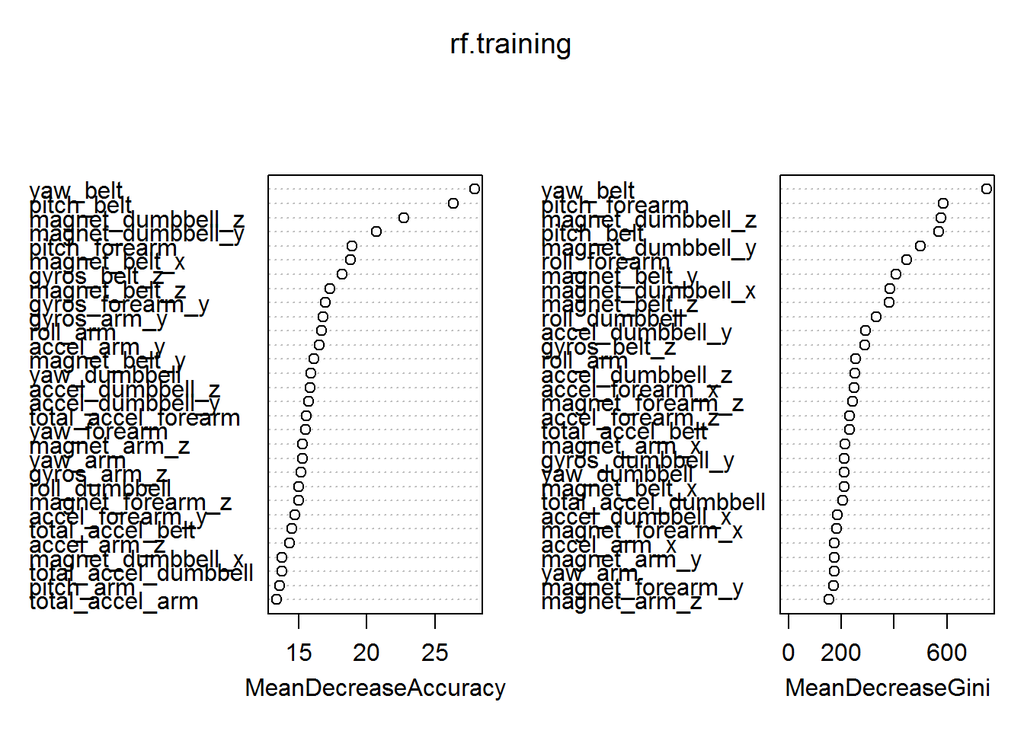

```r
varImpPlot(rf.training,)
```

we can see which variables have higher impact on the prediction.

## Out-of Sample Accuracy

Now lets evaluate this tree on the test data.

```r
tree.pred=predict(rf.training,testing,type="class")
predMatrix = with(testing,table(tree.pred,classe))
sum(diag(predMatrix))/sum(as.vector(predMatrix)) # error rate
```

```
## [1] 0.9969414
```

0.99 means we got a very accurate estimate.

# Conclusion

Now we can predict the testing data from the website

```r
answers <- predict(rf.training, Testingdata)
answers
```

```
##  1  2  3  4  5  6  7  8  9 10 11 12 13 14 15 16 17 18 19 20
##  B  A  B  A  A  E  D  B  A  A  B  C  B  A  E  E  A  B  B  B
## Levels: A B C D E
```